# Indentifying the most representative CIN model

Barbara Hernando, bhernando@cnio.es

Blas Chaves, bchavesu@ext.cnio.es

Geoff Macintyre, gmacintyre@cnio.es

10 septiembre, 2021

### Finding the best model of chromosomal instability

This **CNpare Tool** aims at finding the best cell line model for studying a type of chromosomal instability (CIN) in vitro. To this purpose, the model selection can be based on its copy-number profile or on its exposure to copy-number signatures.

This Rmarkdown is an example of how to use this tool.

We first identified the cell line with the most similar copy-number profile independently of tissue origin.

Then, we selected cell lines of the same tissue origin, quantified the copy-number signatures and obtained a list of cell lines representing the same type of chromosomal instability. For quantifying copy-number signatures, this script implements the computational approach developed by Geoff Macintyre in 2018.

#### 1) Input data

We first get the **RData** files in the `data/` folder:

- `cells_segcn.RData` – Absolute copy-number profiles of cancer cell lines generated with *ASCAT*. The segment tables should have the following column headers: “chromosome”, “start”, “end”, “segVal”, “sample”.
- `cells_mapping.RData` Mapping information of cancer cell lines
- `CCLE_metadata.RData` Metadata of CCLE database for selecting cell lines by tissue origin

#### 2) Get the cell line model with the closest copy-number profile

##### Cell lines data preprocessing

Segmented copy-number profiles of cell lines may be fitted to the genomic positions of bins. Therefore, we split genome in evenly sized bins (default 500 kb) and get their positions.

```r
allchr=c(1:22) #Add 23 if want to include chrX
lengthChr<-lengthChr
posBins <- lapply(allchr,function(chr)
    getBinsStartsEnds(window=500000, chr, lengthChr[chr]))
```

We selected the CCLE models with available copy-number profile. We also selected profiles with detectable CIN (those with at least 20 CNAs in a profile). Therefore, we discarded profiles with non detectable chromosomal instability. Finally, a matrix with copy-numbers per bin is then generated.

```r
ccle<-as.data.frame(cbind(cellid=cells_mapping$cellid[cells_mapping$study=="CCLE"],sample=cells_mapping$fileid[cells_mapping$study=="CCLE"]))
cells_segcn <- cells_segcn[cells_segcn$sample%in%ccle$sample,]
cells_segcn <- getCINProfiles(segcn=cells_segcn, samples=unique(cells_segcn$sample))
cells_segcn <- left_join(cells_segcn,ccle, by="sample")[,c(1:4,6)]
colnames(cells_segcn)[5]<-"sample"

#get copy-number data per bin
ccle_cn <- getCNbins(posBins=posBins, data=cells_segcn, samples=unique(cells_segcn$sample))
```

For this example, we compare the copy-number profile of **OVKATE** (our sample of interest) with the copy-number profiles of the cell line models. We use *four similarity metrics*:

- *Pearson correlation*: An pearson’s r value of exactly 1 indicates that the CN profiles of two samples are equal, although it’s a measure that tolerates whole ploidy shifts. Rank-base comparisons (kendall or spearman correlation tests) are not recommended to be used for comparing CN profiles because they are sensitive to small variations in the segVal or raw copy-number values of segments (noisy profiles).
- *Manhattan distance*: A manhattan distance of exactly 0 indicates that the CN profiles of two samples are equal. Contrary to pearson correlation, this measure does not tolerate whole ploidy shifts.
- *Euclidean distance*: An euclidean distance of exactly 0 indicates that the CN profiles of two samples are equal. As manhattan distance, this distance measure does not tolerate whole ploidy shifts.
- *Cosine similarity*: A cosine similarity of exactly 1 indicates that the CN profiles of two samples are equal. As Pearson correlation, this measure tolerates whole ploidy shifts.

```r
exp_cell=as.matrix(ccle_cn[,colnames(ccle_cn)=="OVKATE"])
colnames(exp_cell)<-"OVKATE"

measures<-getSimilarities(dat1=exp_cell, dat2=ccle_cn, method="all")
```

Then, we can print the cell line with the most similar copy-number profile (lowest manhattan distance). We used the manhattan distance because it is usually preferred over the more common Euclidean distance when there is high dimensionality in the data.

```
#>    fileid         id          r manhattan euclidean   cos_sim
#> 1: OVKATE     OVKATE 1.00000000 0.0000000    0.0000 1.0000000
#> 2: OVKATE Panc 02.03 0.44349956 0.9677936  104.5168 0.9264316
#> 3: OVKATE    CFPAC-1 0.30471025 0.9983585  112.4742 0.9166185
#> 4: OVKATE       SIMA 0.11164371 1.0181089  122.4810 0.9077089
#> 5: OVKATE    JHUEM-1 0.06788905 1.0205010  107.7184 0.9269193
```

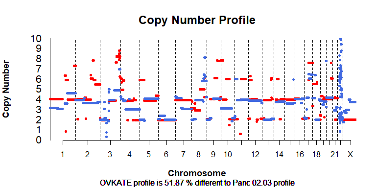

Then, we can print the cell line with the most similar copy-number profile regardless the ploidy (highest pearson’s r value). Interestingly, in this example, the same cell line comes out as the most representative cell line for OVKATE.

```
#>    fileid         id         r manhattan euclidean   cos_sim
#> 1: OVKATE     OVKATE 1.0000000 0.0000000    0.0000 1.0000000
#> 2: OVKATE Panc 02.03 0.4434996 0.9677936  104.5168 0.9264316
#> 3: OVKATE    HMC-1-8 0.3950075 1.1228343  101.8470 0.9106773
#> 4: OVKATE    HCC1428 0.3939883 1.2669674  128.3284 0.8885978
#> 5: OVKATE  NCI-H1437 0.3743621 1.3214229  127.9722 0.9107956
```

##### Visualization of genome differences between two copy-number profiles

CNpare also provides a visual representation of the genome differences. To this functionality, we changed the the default argument ``plot_dif` to TRUE. Here, we plotted differences in PANC0203 respect to OVKATE:

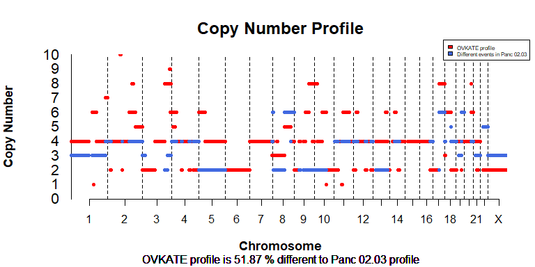

#### 3) Get the cell line models of the same tissue origin representing the CIN type of interest

##### Selection of samples with the same tissue origin

We aim at finding the cell line of the same tissue origin that represents the CIN type operating in **OVKATE** (our sample of interest). We have selected this HGSO cancer cell line because it is known to have extreme CIN. Therefore, we selected profiles of all cell lines derived from ovary tissue.

```r
sample="OVKATE"
cells.tissue<-as.character(na.omit(CCLE_metadata$Cell.line.primary.name[CCLE_metadata$Site.Primary == CCLE_metadata$Site.Primary[CCLE_metadata$Cell.line.primary.name == sample]]))
tissue_segcn<-cells_segcn[cells_segcn$sample %in% cells.tissue,]
tissue.profiles<-getProfiles(segcn=tissue_segcn, samples=unique(tissue_segcn$sample))
```

##### Quantification of copy-number signatures

Now, we generate a matrix with the activity levels of each copy-number signature per sample

```r
component_parameters<-readRDS(paste0(path_to_data,"component_parameters.rds"))

CN_features <- extractCopynumberFeatures(tissue.profiles)
sample_by_component <- generateSampleByComponentMatrix(CN_features, all_components=component_parameters)
signature_quantification <- quantifySignatures(sample_by_component)
```

##### Clustering samples by copy-number signatures

*K-means clustering* (MacQueen, 1967) is the most commonly used unsupervised machine learning algorithm for partitioning a given data set into a set of k groups. Therefore, we will be able to detect similar samples according to copy-number signature exposures.

The first step when using k-means clustering is to indicate the number of clusters (k). Therefore, we first estimated the optimal number of clusters.

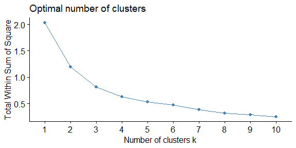

Then, we computed the k-means clustering with k = 4 (optimal as it appears to be the bend in the knee), Principal Components is used to plot data, which is colored according to its cluster assignment.

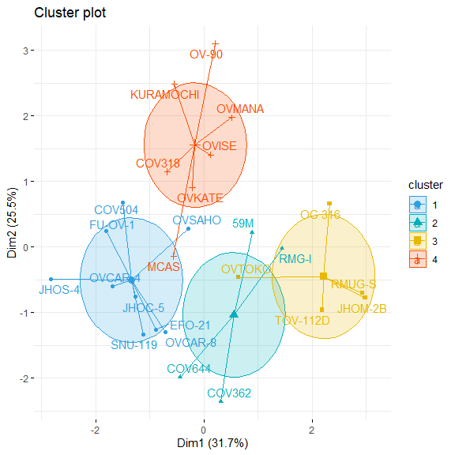